# Final Project - Credit Card Fraud Detection

##### 23. V23

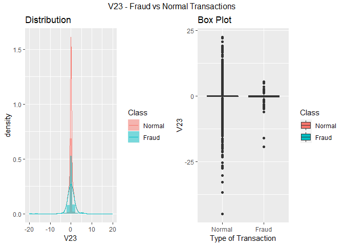

```r
p1 <- ggplot(data, aes(x = V23, fill = Class)) +
   geom_histogram(alpha = 0.5, aes(y = ..density..), position = 'identity') + stat_density(geom = "line", aes(colour = Class), adjust = 10) + xlim(-20,20 ) + labs(title=expression("Distribution"))

p2 <- ggplot(data, aes(y=V23, x=Class)) +  geom_boxplot(aes(fill = Class)) + labs(title=expression("Box Plot")) + xlab("Type of Transaction")

grid.arrange(p1, p2, top="V23 - Fraud vs Normal Transactions", ncol = 2)
```

**Fraud vs Normal comparison**

- The distribution is very similar and there is complete overlap
- The variability in data is also similar
- Therefore, this variable **may not be useful** in predicting the fraud

##### 24. V24

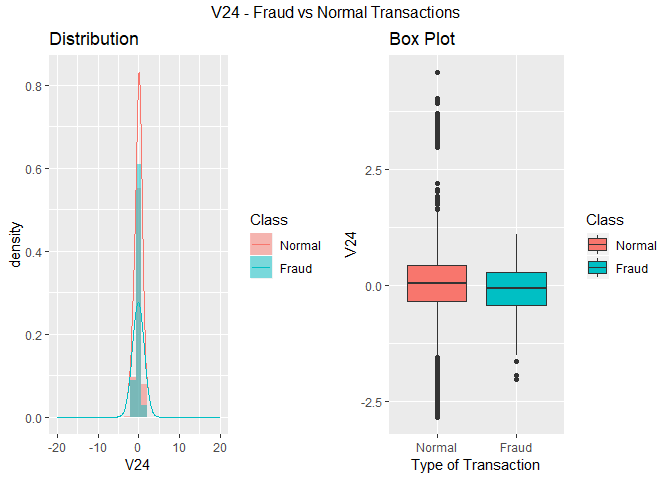

```r
p1 <- ggplot(data, aes(x = V24, fill = Class)) +
   geom_histogram(alpha = 0.5, aes(y = ..density..), position = 'identity') + stat_density(geom = "line", aes(colour = Class), adjust = 10) + xlim(-20,20 ) + labs(title=expression("Distribution"))

p2 <- ggplot(data, aes(y=V24, x=Class)) +  geom_boxplot(aes(fill = Class)) + labs(title=expression("Box Plot")) + xlab("Type of Transaction")

grid.arrange(p1, p2, top="V24 - Fraud vs Normal Transactions", ncol = 2)
```

**Fraud vs Normal comparison**

- The distribution is very similar and there is complete overlap
- The variability in data is also similar
- Therefore, this variable **may not be useful** in predicting the fraud

##### 25. V25

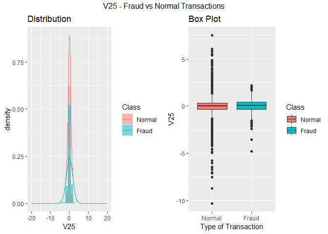

```r
p1 <- ggplot(data, aes(x = V25, fill = Class)) +
   geom_histogram(alpha = 0.5, aes(y = ..density..), position = 'identity') + stat_density(geom = "line", aes(colour = Class), adjust = 10) + xlim(-20,20 ) + labs(title=expression("Distribution"))

p2 <- ggplot(data, aes(y=V25, x=Class)) +  geom_boxplot(aes(fill = Class)) + labs(title=expression("Box Plot")) + xlab("Type of Transaction")

grid.arrange(p1, p2, top="V25 - Fraud vs Normal Transactions", ncol = 2)
```

**Fraud vs Normal comparison**

- The distribution is very similar and there is complete overlap
- The variability in data is also similar
- Therefore, this variable **may not be useful** in predicting the fraud

##### 26. V26

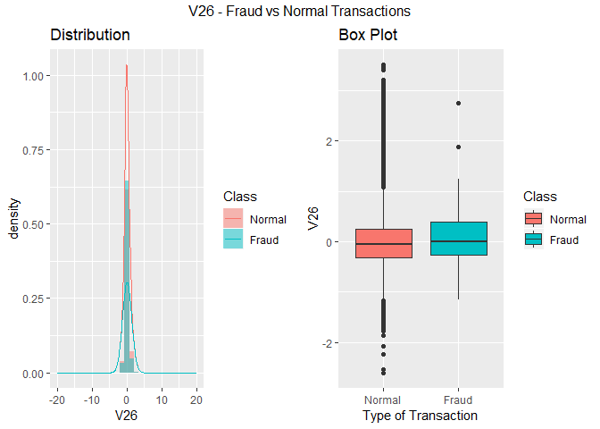

```r
p1 <- ggplot(data, aes(x = V26, fill = Class)) +
   geom_histogram(alpha = 0.5, aes(y = ..density..), position = 'identity') + stat_density(geom = "line", aes(colour = Class), adjust = 10) + xlim(-20,20 ) + labs(title=expression("Distribution"))

p2 <- ggplot(data, aes(y=V26, x=Class)) +  geom_boxplot(aes(fill = Class)) + labs(title=expression("Box Plot")) + xlab("Type of Transaction")

grid.arrange(p1, p2, top="V26 - Fraud vs Normal Transactions", ncol = 2)
```

**Fraud vs Normal comparison**

- The distribution is very similar and there is complete overlap
- The variability in data is also similar
- Therefore, this variable **may not be useful** in predicting the fraud

##### 27. V27

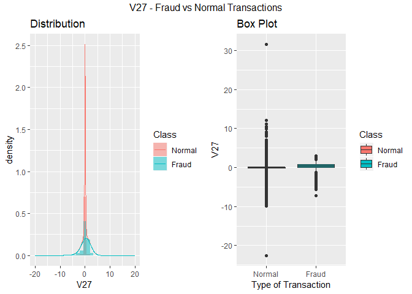

```r
p1 <- ggplot(data, aes(x = V27, fill = Class)) +
   geom_histogram(alpha = 0.5, aes(y = ..density..), position = 'identity') + stat_density(geom = "line", aes(colour = Class), adjust = 10) + xlim(-20,20 ) + labs(title=expression("Distribution"))

p2 <- ggplot(data, aes(y=V27, x=Class)) +  geom_boxplot(aes(fill = Class)) + labs(title=expression("Box Plot")) + xlab("Type of Transaction")

grid.arrange(p1, p2, top="V27 - Fraud vs Normal Transactions", ncol = 2)
```

**Fraud vs Normal comparison**

- The distribution is very similar and there is complete overlap
- The variability in data is also similar
- Therefore, this variable **may not be useful** in predicting the fraud

##### 28. V28

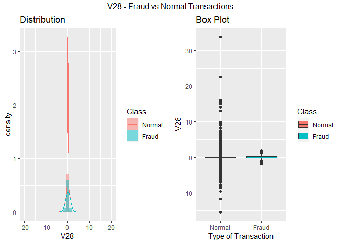

```r
p1 <- ggplot(data, aes(x = V28, fill = Class)) +
   geom_histogram(alpha = 0.5, aes(y = ..density..), position = 'identity') + stat_density(geom = "line", aes(colour = Class), adjust = 10) + xlim(-20,20 ) + labs(title=expression("Distribution"))

p2 <- ggplot(data, aes(y=V28, x=Class)) +  geom_boxplot(aes(fill = Class)) + labs(title=expression("Box Plot")) + xlab("Type of Transaction")

grid.arrange(p1, p2, top="V28 - Fraud vs Normal Transactions", ncol = 2)
```

**Fraud vs Normal comparison**

- The distribution is very similar and there is complete overlap
- The variability in data is also similar
- Therefore, this variable **may not be useful** in predicting the fraud

##### Brief Summary of V1-V28 Analysis So Far

- Variables that have clearly seperated distribution by class: V4, V11, V12
- Variables that have partially seperated distribution by class: V1, V2, V3, V9, V10
- Variables that have similar mean but with different distributions by class: v5, v6, v7, v8, v14, v16, v17, v18, v19, v20, v21, v22, v23, v27, v28
- Variables that have similar profiles by class V13, V15, V22, V25, V26

## 7. Conclusion of Exploratory Data Analysis

**Data overview** The dataset has around 285k values with 31 variables, out of which 1 value is missing, and all data are unique. That missing value is one missing transaction time. Three variables are original variables: Class, Time, and Amount. The rest are masked variables due to the sensitive personal information (V1 - V28)

**Target Variable Analysis** By plotting the class by the frequency of fraud vs not fraud, we found that this is an unbalanced data with less than 0.2% of fraud transactions.

**Transaction Time Analysis** - Transform the Time into day and night we see that most valid transactions take place during the day whereas fraud is more likely to happen than normal transactions during the night. - Analyze the time by class we see that the mean time for valid transaction is larger than that of fraud. - Normal transactions follow a cyclical period. - Therefore, if large number of transaction shows up in low acitivity period it can raise an alarm.

**Transaction Amount Analysis** - Most of the transactions appear to be of small amount for both fraud and clean transactions, but fraud transactions have some outliers of large amount - 60% of the transactions are of amount less than ~$40 - No particular anomaly based on amount of the transaction

**Amount and Time Analysis** Fit the transaction amount by its time we see that there is also no particular anomoly between fraud and normal transaction. So transaction amount does not have a significant correlation with clean transaction

**Blind Data Analysis** The correlation map shows that: - None of the V1 to V28 PCA components have any correlation to each other: it is highly likely that they are already transformed into principle components. - Time has some correlations with V components but not much with Amount. - Amount also has some correlations with V components but not much with Time. - Class has some positive and negative correlations with the V components but has no significant correlation with Time and Amount.

Transformed components are hard to interpret based on instinct, but they are powerful variables in developing our model because selection bias is eliminated. Based on the individual analysis of these variables by target class, these masked variables are divided into following groups: a) Variables that have clearly seperated distribution by class: V4, V11, V12

2. Variables that have partially seperated distribution by class: V1, V2, V3, V9, V10
3. Variables that have similar mean but with different distributions by class: v5, v6, v7, v8, v14, v16, v17, v18, v19, v20, v21, v22, v23, v27, v28
4. Variables that have similar profiles by class V13, V15, V22, V25, V26

Group a,b,and c could be good predictors in the importance rank of a>b>c. Group d is relatively irrelevant to the target variable.

# 3. Results and Discussion

## Create model

In this section, we will train 3 models on our training data: gbm, random forest and knn. Subsequently, we will apply all three models on the testing data for comparison.

### GBM

```r
h2o.init()
```

```
##  Connection successful!
##
## R is connected to the H2O cluster:
##     H2O cluster uptime:         2 hours 53 minutes
##     H2O cluster timezone:       America/New_York
##     H2O data parsing timezone:  UTC
##     H2O cluster version:        3.20.0.8
##     H2O cluster version age:    2 months and 21 days
##     H2O cluster name:           H2O_started_from_R_Chi_Zhang_rko792
##     H2O cluster total nodes:    1
##     H2O cluster total memory:   3.07 GB
##     H2O cluster total cores:    8
##     H2O cluster allowed cores:  8
##     H2O cluster healthy:        TRUE
##     H2O Connection ip:          localhost
##     H2O Connection port:        54321
##     H2O Connection proxy:       NA
##     H2O Internal Security:      FALSE
##     H2O API Extensions:         Algos, AutoML, Core V3, Core V4
##     R Version:                  R version 3.5.1 (2018-07-02)
```

##### Prepare Model

```r
data_gbm <- h2o.importFile("creditcard.csv")
```

Create a list of predictors and change the predicted variable to factor.

```r
response <- "Class"
data_gbm[[response]] <- as.factor(data_gbm[[response]])
predictors <- setdiff(names(data_gbm),response)
```

Split the data into train and test using a ratio of 7:3

```r
splits <- h2o.splitFrame(
  data = data_gbm,
  ratios = 0.7,
  seed = 1
)

train_gbm <- splits[[1]]
test_gbm <- splits[[2]]
```

##### Training Model

```r
gbm <- h2o.gbm(
  ## standard model parameters
  x = predictors,
  y = response,
  training_frame = train_gbm,
  validation_frame = test_gbm,
  #cross validation using 5 folds
  nfolds = 5,
  fold_assignment = "Stratified",
  balance_classes = TRUE,
  distribution = "bernoulli",
  ## more trees is better if the learning rate is small enough
  ## here, we want to use "more than enough" trees as we have early   ## stopping
  ntrees = 1000,
  ## smaller learning rate is better
  learn_rate=0.01,
  ## early stopping once the validation auc doesn't improve by at least 0.01% for 5 consecutive scoring events
  stopping_rounds = 5, stopping_tolerance = 1e-4, stopping_metric = "AUC",
  ## sample 80% of rows per tree
  sample_rate = 0.8,
  ## sample 80% of columns per split
  col_sample_rate = 0.8,
  ## fix a random number generator seed for reproducibility
  seed = 1234,
  ## score every 10 trees to make early stopping reproducible (it depends on the scoring interval)
  score_tree_interval = 10
)
```

##### Model Performance & Analysis

```r
gbm@model$cross_validation_metrics_summary
```

```
## Cross-Validation Metrics Summary:
##                                 mean           sd   cv_1_valid
## accuracy                    0.999389    7.3863E-5    0.9994765
## auc                        0.9747278 0.0069145868   0.98600763
## err                     6.1102305E-4    7.3863E-5   5.23508E-4
## err_count                       24.4    2.9866369         21.0
## f0point5                     0.84314  0.022227274   0.86567163
## f1                         0.8131731  0.025655914   0.84671533
## f2                         0.7856518   0.03069498   0.82857144
## lift_top_group             85.622536     1.406148     88.54257
## logloss                  0.008109547   8.03796E-4  0.008381526
## max_per_class_error       0.23149234  0.034275115   0.18309858
## mcc                        0.8145755   0.02520977   0.84701973
## mean_per_class_accuracy    0.8841485  0.017132988    0.9083508
## mean_per_class_error      0.11585153  0.017132988   0.09164919
## mse                     0.0016962221 2.0501921E-4 0.0017209258
## precision                   0.864659   0.02196842    0.8787879
## r2                       0.036913462 0.0079756575  0.025977204
## recall                    0.76850766  0.034275115    0.8169014
## rmse                     0.041029442 0.0025305108  0.041484043
## specificity                0.9997893   3.63451E-5    0.9998002
##                           cv_2_valid   cv_3_valid   cv_4_valid
## accuracy                  0.99920267    0.9993739   0.99949825
## auc                       0.98039633    0.9684447   0.97994024
## err                      7.973488E-4  6.260643E-4 5.0178135E-4
## err_count                       32.0         25.0         20.0
## f0point5                  0.84577113     0.844504        0.875
## f1                         0.8095238    0.8344371    0.8305085
## f2                         0.7762557    0.8246073    0.7903226
## lift_top_group             85.412964     86.00501     85.84704
## logloss                  0.009514571  0.008861865  0.007564227
## max_per_class_error       0.24444444   0.18181819     0.234375
## mcc                       0.81120706    0.8342889    0.8332654
## mean_per_class_accuracy    0.8776529    0.9089529    0.8827497
## mean_per_class_error      0.12234709   0.09104709   0.11725032
## mse                     0.0021062193 0.0018580673 0.0015520483
## precision                  0.8717949    0.8513514    0.9074074
## r2                       0.058679014  0.034549437  0.031858917
## recall                    0.75555557    0.8181818     0.765625
## rmse                     0.045893565  0.043105304  0.039396044
## specificity               0.99975026     0.999724   0.99987435
##                           cv_5_valid
## accuracy                   0.9993936
## auc                       0.95885015
## err                      6.064128E-4
## err_count                       24.0
## f0point5                   0.7847534
## f1                         0.7446808
## f2                          0.708502
## lift_top_group              82.30511
## logloss                  0.006225547
## max_per_class_error        0.3137255
## mcc                        0.7470965
## mean_per_class_accuracy   0.84303606
## mean_per_class_error      0.15696394
## mse                     0.0012438498
## precision                 0.81395346
## r2                       0.033502735
## recall                     0.6862745
## rmse                     0.035268255
## specificity                0.9997976
```

```r
h2o.confusionMatrix(gbm, valid = TRUE)
```

```
## Confusion Matrix (vertical: actual; across: predicted)  for max f1 @ threshold = 0.0168436925900475:
##            0   1    Error       Rate
## 0      85044  10 0.000118  =10/85054
## 1         27 112 0.194245    =27/139
## Totals 85071 122 0.000434  =37/85193
```

- The sensitity rate is about 1-27/139 = 81%, which indicates we are able to identity fraud correctly 81% of the time. We have an overall accuracy of 99.9%.

```r
h2o.varimp(gbm)
```

```
## Variable Importances:
##   variable relative_importance scaled_importance percentage
## 1      V14      2880564.000000          1.000000   0.651861
## 2      V10       613102.937500          0.212841   0.138743
## 3       V4       296229.750000          0.102837   0.067036
## 4      V12       180488.750000          0.062657   0.040844
## 5      V19        31807.957031          0.011042   0.007198
##
## ---
##    variable relative_importance scaled_importance percentage
## 25      V24         9063.727539          0.003147   0.002051
## 26       V9         5464.617676          0.001897   0.001237
## 27       V6         5280.549805          0.001833   0.001195
## 28      V28         4115.596680          0.001429   0.000931
## 29       V2         2229.754639          0.000774   0.000505
## 30      V27         1552.119751          0.000539   0.000351
```

- V14, V10 and V4 are determined to be the most important variables in the GBM model.

```r
prediction = h2o.predict(gbm, newdata=test_gbm)
head(prediction)
```

```
##   predict        p0           p1
## 1       0 0.9998259 0.0001740936
## 2       0 0.9997362 0.0002638312
## 3       0 0.9998477 0.0001523153
## 4       0 0.9998472 0.0001527742
## 5       0 0.9998539 0.0001461339
## 6       0 0.9998483 0.0001516769
```

```r
pred = as.data.frame(prediction)
perf = h2o.performance(gbm, newdata=test_gbm)

h2o.auc(perf)
```

```
## [1] 0.9729901
```

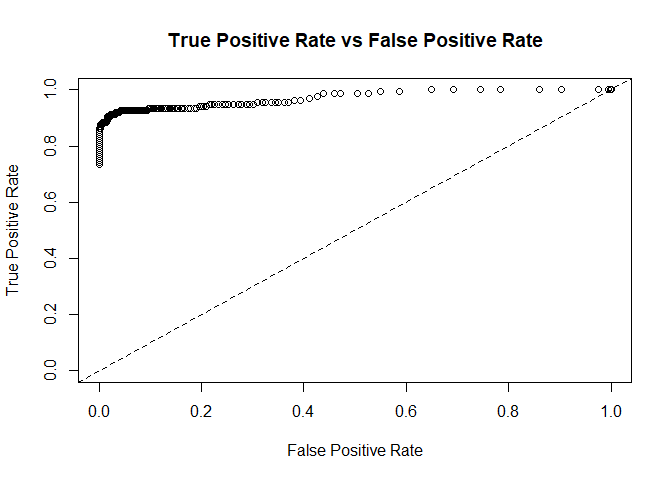

```r
plot(perf, type = "roc")
```

- Conclusion: The model results in an AUC of 97.3%. The ROC graph shown above indicates we have a very good model predicting true positives. This gives us a high sensitivity which is useful in predicting fraudulent transactions.

### Random Forest

##### Prepare Model

Data spliting: we use the same training and testing set from our first model

```r
train<- as.data.frame(train_gbm)
levels(train$Class) <- c("NotFraud", "Fraud")
test <- as.data.frame(test_gbm)
levels(test$Class) <- c("NotFraud", "Fraud")
```

```r
basic_rec <- recipe(Class ~ .,
                    data = train) %>%
     # remove variables that contain only a single value
     step_zv(all_predictors())
```

Rf grid and control

```r
ctrl <- trainControl(
      # use 10-fold CV to resample the data
     method = "cv",
     #  compute probabilities for our classification model in each resample
     classProbs = TRUE,
     # produce ROC,AUC along with sensitivity and specificity from the default 50% cutoff
     summaryFunction = twoClassSummary,
     savePredictions = 'final',
     # downsamping done instide of the resampling
     sampling = 'down',
     verboseIter = FALSE)
rf_grid <- expand.grid(
    # use the classic squre root of the observation # for number of the # of variables at each split
    .mtry = c(6)
            )
```

- Because there are imbalances in the class of our data, we might be facing overfitting issues to the majority class. In order to solve this, we down-sample the data to balance the number of “Fraud” and “NotFraud”.

##### Training Model

```r
cl <- makeCluster(8)
registerDoParallel(cl)

rf_mod <- train(basic_rec,
                 data = train,
                 method = 'rf',
                 metric = "ROC",
                 tuneGrid = rf_grid,
                 trControl = ctrl,
                 # set to grow 500 trees
                 ntree = 500,
                 verbose = FALSE,
                importance = TRUE)
stopCluster(cl)
```

##### Model Performance & Analysis

Variable Importance

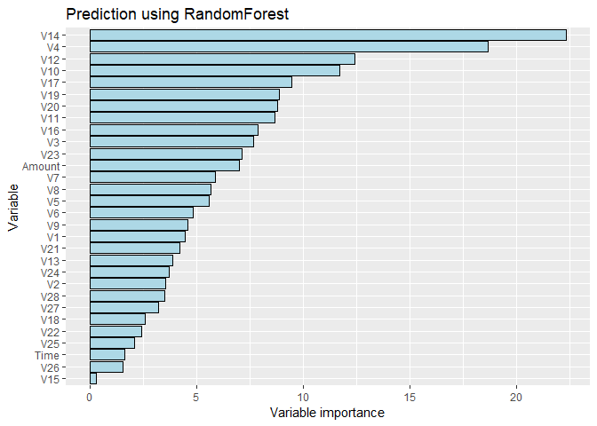

```r
imp <- varImp(rf_mod, scale = FALSE,
                   surrogates = FALSE,
                   competes = FALSE)
imp1 <- ggplot(imp, aes(x=reorder(rownames(imp)), y = importance)) +
  geom_bar(stat="identity", fill="lightblue", colour="black") +
  coord_flip() +
  labs(title="Prediction using RandomForest", x="Variable", y="Variable importance")
imp1
```

```r
draw_confusion_matrix <- function(test, title) {
    tst <- data.frame(test$predicted, test$Class)
    opts <-  c("Prediction", "True")
    names(tst) <- opts
    cf <- plyr::count(tst)
    cf[opts][cf[opts]==0] <- "Not Fraud"
    cf[opts][cf[opts]==1] <- "Fraud"

    ggplot(data =  cf, mapping = aes(x = True, y = Prediction)) +
      labs(title = "Confusion Matrix", subtitle = title) +
      geom_tile(aes(fill = freq), colour = "black") +
      geom_text(aes(label = sprintf("%1.0f", freq)), vjust = 1) +
      scale_fill_gradient(low = "lightgreen", high = "green") +
      theme_bw() + theme(legend.position = "none")}
```

```r
test$predicted <- predict(rf_mod ,test)
confusionMatrix(rf_mod)
```

```
## Cross-Validated (10 fold) Confusion Matrix
##
## (entries are percentual average cell counts across resamples)
##
##           Reference
## Prediction NotFraud Fraud
##   NotFraud     97.0   0.0
##   Fraud         2.8   0.2
##
##  Accuracy (average) : 0.9715
```

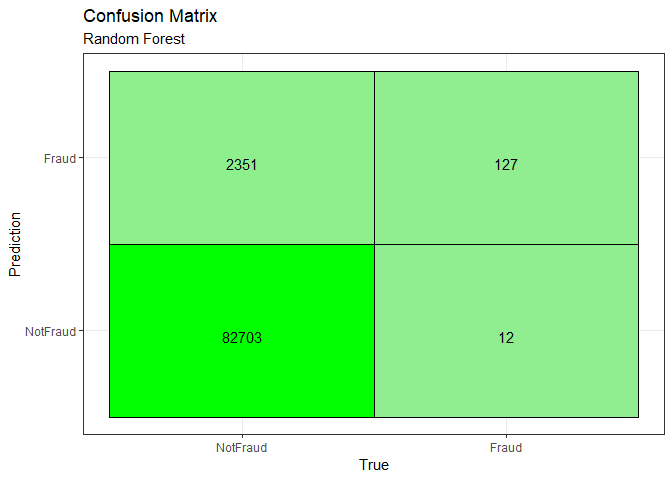

```r
draw_confusion_matrix(test,"Random Forest")
```

```r
print(rf_mod)
```

```
## Random Forest
##
## 199614 samples
##     30 predictor
##      2 classes: 'NotFraud', 'Fraud'
##
## Recipe steps: zv
## Resampling: Cross-Validated (10 fold)
## Summary of sample sizes: 179652, 179652, 179653, 179653, 179652, 179653, ...
## Addtional sampling using down-sampling
##
## Resampling results:
##
##   ROC        Sens       Spec
##   0.9824811  0.9716252  0.9092857
##
## Tuning parameter 'mtry' was held constant at a value of 6
```

```r
plot_roc <- function(x, ...) {
  roc_obj <- roc(
    response = x[["obs"]],
    predictor = x[["Fraud"]],
    levels = rev(levels(x$obs))
  )
  plot(roc_obj, ...)
  matplot(data.frame(roc_obj$sensitivities, roc_obj$specificities), x = roc_obj$thresholds,
      type='l',
  xlab = 'threshold', ylab='TPR, TNR')
  legend('bottomright', legend=c('TPR', 'TNR'))
   # include the area under curve
  return(auc(roc_obj))
  }
```

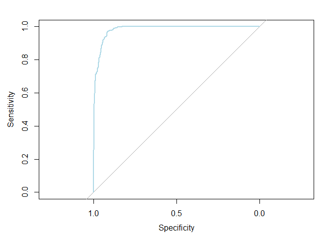

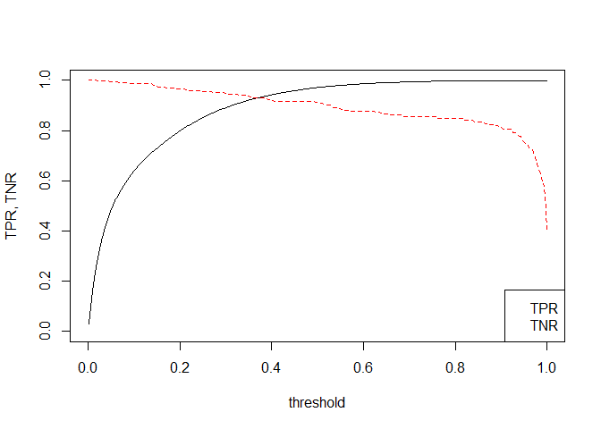

```
## Area under the curve: 0.9815
```

```r
plot_roc(rf_mod$pred,col = "lightblue")
```

- Conclusion: Though the model produces a great accuracy, the accuracy calculated in our model may not be as meaningful due to the imbalances in our class. We see that threshhold around 0.3 is where TPR equals TNR, and we get a good AUC of 0.982.

### KNN

We believe the tree models will work great with the imbalanced data set. Just a curiosity, we predicted using a non-tree model - knn and compared the results as below.

##### Prepare Model

- Due to imbalances, this time we use both downsampling and upsampling technique to get a raletively balanced data set.

```r
data_both <- ovun.sample(Class ~ ., data = train, method = "both", p=0.5, N=10000, seed = 123)$data
table(data_both$Class)
```

```
##
## NotFraud    Fraud
##     5057     4943
```

As you can see, the data after sampling is much more balanced.

```r
#Run KNN Model for Data Set
cl <- makeCluster(8)
registerDoParallel(cl)
control <- trainControl(method="repeatedcv", number=10, repeats=3, savePredictions=TRUE, classProbs=TRUE)
set.seed(222)
knn_both_mod <- train(Class~., data=data_both, trControl=control, method = "knn")

stopCluster(cl)
```

```r
#Predict Model on Test Set
pred_both <- predict(knn_both_mod, newdata = test)
```

```r
#Evaluate the Model by Looking at the ConfusionMatrix
confusionMatrix(test$Class, pred_both, positive = "Fraud")
```

```
## Confusion Matrix and Statistics
##
##           Reference
## Prediction NotFraud Fraud
##   NotFraud    68856 16198
##   Fraud          65    74
##
##                Accuracy : 0.8091
##                  95% CI : (0.8064, 0.8117)
##     No Information Rate : 0.809
##     P-Value [Acc > NIR] : 0.4708
##
##                   Kappa : 0.0058
##  Mcnemar's Test P-Value : <2e-16
##
##             Sensitivity : 0.0045477
##             Specificity : 0.9990569
##          Pos Pred Value : 0.5323741
##          Neg Pred Value : 0.8095563
##              Prevalence : 0.1910016
##          Detection Rate : 0.0008686
##    Detection Prevalence : 0.0016316
##       Balanced Accuracy : 0.5018023
##
##        'Positive' Class : Fraud
##
```

- As expected, the knn model did not do well predicting on the test set due to the highly imbalanced nature of the data set. Many data points will automatically be classified as non-fraudulent due to the large volume of non-fraudulent neightbors. Therefore, we exclude this model from our predictions on the data set, and compare only the gbm and random forest models.

## Model Comparison & Conclusion

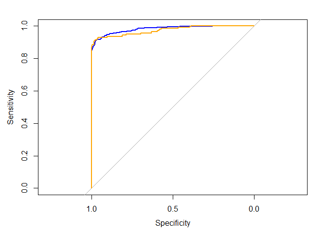

```r
gbm_pred_df <- cbind(test,pred)

gbm_pred_df <- gbm_pred_df %>%
  mutate(fraud = if_else(predict == 0, 1-p0, p0))

plot(roc(rf_mod$pred$obs, rf_mod$pred$Fraud, thresholds = 0.3), col = 'blue')
plot(roc(gbm_pred_df$Class, gbm_pred_df$fraud), add = TRUE, col = 'orange')
```

# 4.Conclusion

In this project we have used three machine learning models to predict fraudulent transactions on a highly imbalanced data of credit card transactions in September 2013 by European cardholders. The results were very promising for tree-based models i.e. Random Forest and Gradient Boosting (with H2O). Random forest had an AUC value of 98.2% while GBM had an AUC value of 97.3%

Based on our analysis, we found that these algorithms performed better because they were able to balance the class variable effectively. Moreover, number of features can be reduced using the Principal Component Analysis concept to improve the running time of the classification algorithm.

We noted that the choosing the right balance between sensitivity, specificity and accuracy is pivotal for an imbalance data like credit card fraud logs. Usually it is desirable to have higher accuracy and sensitivity for prediction but our rigorous data engineering revealed that for financial data like credit card fraud logs, it makes more sense to aim for higher sensitivity for accurate prediction of fraudulent transactions.